# DATA VISUALIZATION PROJECT

# REVIEW 1

**Importing required packages**

```python
import sys
import pandas as pd
import numpy as np
import seaborn as sns
import category_encoders as ce
import matplotlib.pyplot as plt

import warnings
warnings.simplefilter(action='ignore', category=FutureWarning)
pd.options.mode.chained_assignment=None

sns.set_style(style="whitegrid")
```

**Importing the used vehicles dataset to predict their selling price**

```python
car_ds=pd.read_csv(r'C:\Users\keert\Downloads\Car details v3.csv')
```

```python
car_ds
```

|  | name | year | selling_price | km_driven | fuel | seller_type | transmission | owner | mileage | engine | max_power | torque | seats |
| --- | --- | --- | --- | --- | --- | --- | --- | --- | --- | --- | --- | --- | --- |
| 0 | Maruti Swift Dzire VDI | 2014 | 450000 | 145500 | Diesel | Individual | Manual | First Owner | 23.4 kmpl | 1248 CC | 74 bhp | 190Nm@ 2000rpm | 5.0 |
| 1 | Skoda Rapid 1.5 TDI Ambition | 2014 | 370000 | 120000 | Diesel | Individual | Manual | Second Owner | 21.14 kmpl | 1498 CC | 103.52 bhp | 250Nm@ 1500-2500rpm | 5.0 |
| 2 | Honda City 2017-2020 EXi | 2006 | 158000 | 140000 | Petrol | Individual | Manual | Third Owner | 17.7 kmpl | 1497 CC | 78 bhp | 12.7@ 2,700(kgm@ rpm) | 5.0 |
| 3 | Hyundai i20 Sportz Diesel | 2010 | 225000 | 127000 | Diesel | Individual | Manual | First Owner | 23.0 kmpl | 1396 CC | 90 bhp | 22.4 kgm at 1750-2750rpm | 5.0 |
| 4 | Maruti Swift VXI BSIII | 2007 | 130000 | 120000 | Petrol | Individual | Manual | First Owner | 16.1 kmpl | 1298 CC | 88.2 bhp | 11.5@ 4,500(kgm@ rpm) | 5.0 |
| ... | ... | ... | ... | ... | ... | ... | ... | ... | ... | ... | ... | ... | ... |
| 8123 | Hyundai i20 Magna | 2013 | 320000 | 110000 | Petrol | Individual | Manual | First Owner | 18.5 kmpl | 1197 CC | 82.85 bhp | 113.7Nm@ 4000rpm | 5.0 |
| 8124 | Hyundai Verna CRDi SX | 2007 | 135000 | 119000 | Diesel | Individual | Manual | Fourth & Above Owner | 16.8 kmpl | 1493 CC | 110 bhp | 24@ 1,900-2,750(kgm@ rpm) | 5.0 |
| 8125 | Maruti Swift Dzire ZDi | 2009 | 382000 | 120000 | Diesel | Individual | Manual | First Owner | 19.3 kmpl | 1248 CC | 73.9 bhp | 190Nm@ 2000rpm | 5.0 |
| 8126 | Tata Indigo CR4 | 2013 | 290000 | 25000 | Diesel | Individual | Manual | First Owner | 23.57 kmpl | 1396 CC | 70 bhp | 140Nm@ 1800-3000rpm | 5.0 |
| 8127 | Tata Indigo CR4 | 2013 | 290000 | 25000 | Diesel | Individual | Manual | First Owner | 23.57 kmpl | 1396 CC | 70 bhp | 140Nm@ 1800-3000rpm | 5.0 |

8128 rows × 13 columns

**Rows and columns in the dataset**

```python
car_ds.shape
```

```
(8128, 13)
```

**Attributes in the dataset**

```python
car_ds.columns
```

```
Index(['name', 'year', 'selling_price', 'km_driven', 'fuel', 'seller_type',
       'transmission', 'owner', 'mileage', 'engine', 'max_power', 'torque',
       'seats'],
      dtype='object')
```

**Datatype and number of non null values in each attribute of the dataset**

```python
car_ds.info()
```

```
<class 'pandas.core.frame.DataFrame'>
RangeIndex: 8128 entries, 0 to 8127
Data columns (total 13 columns):
 #   Column         Non-Null Count  Dtype
---  ------         --------------  -----
 0   name           8128 non-null   object
 1   year           8128 non-null   int64
 2   selling_price  8128 non-null   int64
 3   km_driven      8128 non-null   int64
 4   fuel           8128 non-null   object
 5   seller_type    8128 non-null   object
 6   transmission   8128 non-null   object
 7   owner          8128 non-null   object
 8   mileage        7907 non-null   object
 9   engine         7907 non-null   object
 10  max_power      7913 non-null   object
 11  torque         7906 non-null   object
 12  seats          7907 non-null   float64
dtypes: float64(1), int64(3), object(9)
memory usage: 825.6+ KB
```

**Statistical description of each numerical attribute in the dataset**

```python
car_ds.describe()
```

|  | year | selling_price | km_driven | seats |
| --- | --- | --- | --- | --- |
| count | 8128.000000 | 8.128000e+03 | 8.128000e+03 | 7907.000000 |
| mean | 2013.804011 | 6.382718e+05 | 6.981951e+04 | 5.416719 |
| std | 4.044249 | 8.062534e+05 | 5.655055e+04 | 0.959588 |
| min | 1983.000000 | 2.999900e+04 | 1.000000e+00 | 2.000000 |
| 25% | 2011.000000 | 2.549990e+05 | 3.500000e+04 | 5.000000 |
| 50% | 2015.000000 | 4.500000e+05 | 6.000000e+04 | 5.000000 |
| 75% | 2017.000000 | 6.750000e+05 | 9.800000e+04 | 5.000000 |
| max | 2020.000000 | 1.000000e+07 | 2.360457e+06 | 14.000000 |

**Removing the units from the instances and renaming attribute names with their unit**

**Renaming columns**

```python
car_ds.rename(columns={"name":"Name","year":"Year","selling_price":"Selling_price","km_driven":"Km_driven","fuel":"Fuel","seller_type":"Seller_type","transmission":"Transmission","owner":"Owner","mileage":"Mileage(kmpl)","engine":"Engine(CC)","max_power":"Max_power(bhp)","torque":"Torque","seats":"Seats"},inplace=True)
```

**Removing units from instances**

```python
car_ds['Mileage(kmpl)'].replace(' kmpl', '', inplace=True, regex=True)
car_ds['Mileage(kmpl)'].replace(' km/kg', '', inplace=True, regex=True)
car_ds['Max_power(bhp)'].replace(' bhp', '', inplace=True, regex=True)
car_ds['Engine(CC)'].replace(' CC', '', inplace=True, regex=True)
```

```python
car_ds
```

|  | Name | Year | Selling_price | Km_driven | Fuel | Seller_type | Transmission | Owner | Mileage(kmpl) | Engine(CC) | Max_power(bhp) | Torque | Seats |
| --- | --- | --- | --- | --- | --- | --- | --- | --- | --- | --- | --- | --- | --- |
| 0 | Maruti Swift Dzire VDI | 2014 | 450000 | 145500 | Diesel | Individual | Manual | First Owner | 23.4 | 1248 | 74 | 190Nm@ 2000rpm | 5.0 |
| 1 | Skoda Rapid 1.5 TDI Ambition | 2014 | 370000 | 120000 | Diesel | Individual | Manual | Second Owner | 21.14 | 1498 | 103.52 | 250Nm@ 1500-2500rpm | 5.0 |
| 2 | Honda City 2017-2020 EXi | 2006 | 158000 | 140000 | Petrol | Individual | Manual | Third Owner | 17.7 | 1497 | 78 | 12.7@ 2,700(kgm@ rpm) | 5.0 |
| 3 | Hyundai i20 Sportz Diesel | 2010 | 225000 | 127000 | Diesel | Individual | Manual | First Owner | 23.0 | 1396 | 90 | 22.4 kgm at 1750-2750rpm | 5.0 |
| 4 | Maruti Swift VXI BSIII | 2007 | 130000 | 120000 | Petrol | Individual | Manual | First Owner | 16.1 | 1298 | 88.2 | 11.5@ 4,500(kgm@ rpm) | 5.0 |
| ... | ... | ... | ... | ... | ... | ... | ... | ... | ... | ... | ... | ... | ... |
| 8123 | Hyundai i20 Magna | 2013 | 320000 | 110000 | Petrol | Individual | Manual | First Owner | 18.5 | 1197 | 82.85 | 113.7Nm@ 4000rpm | 5.0 |
| 8124 | Hyundai Verna CRDi SX | 2007 | 135000 | 119000 | Diesel | Individual | Manual | Fourth & Above Owner | 16.8 | 1493 | 110 | 24@ 1,900-2,750(kgm@ rpm) | 5.0 |
| 8125 | Maruti Swift Dzire ZDi | 2009 | 382000 | 120000 | Diesel | Individual | Manual | First Owner | 19.3 | 1248 | 73.9 | 190Nm@ 2000rpm | 5.0 |
| 8126 | Tata Indigo CR4 | 2013 | 290000 | 25000 | Diesel | Individual | Manual | First Owner | 23.57 | 1396 | 70 | 140Nm@ 1800-3000rpm | 5.0 |
| 8127 | Tata Indigo CR4 | 2013 | 290000 | 25000 | Diesel | Individual | Manual | First Owner | 23.57 | 1396 | 70 | 140Nm@ 1800-3000rpm | 5.0 |

8128 rows × 13 columns

**Changing the datatype of few attributes after removing the unit from the instances**

```python
car_ds[['Mileage(kmpl)','Engine(CC)','Max_power(bhp)']]=car_ds[['Mileage(kmpl)','Engine(CC)','Max_power(bhp)']].apply(pd.to_numeric)
```

```python
car_ds['Year']=car_ds['Year'].astype('object')
car_ds['Seats']=car_ds['Seats'].replace([2,4,5,6,7,8,9,10,14],['two','four','five','six','seven','eight','nine','ten','fourteen'])
```

**Datatype of each attribute in dataset**

```python
car_ds.dtypes
```

```
Name               object
Year               object
Selling_price       int64
Km_driven           int64
Fuel               object
Seller_type        object
Transmission       object
Owner              object
Mileage(kmpl)     float64
Engine(CC)        float64
Max_power(bhp)    float64
Torque             object
Seats              object
dtype: object
```

**Classifying the attributes based on categorical values**

```python
car_cat=car_ds.select_dtypes(include=['object']).copy()
car_cat
```

|  | Name | Year | Fuel | Seller_type | Transmission | Owner | Torque | Seats |
| --- | --- | --- | --- | --- | --- | --- | --- | --- |
| 0 | Maruti Swift Dzire VDI | 2014 | Diesel | Individual | Manual | First Owner | 190Nm@ 2000rpm | five |
| 1 | Skoda Rapid 1.5 TDI Ambition | 2014 | Diesel | Individual | Manual | Second Owner | 250Nm@ 1500-2500rpm | five |
| 2 | Honda City 2017-2020 EXi | 2006 | Petrol | Individual | Manual | Third Owner | 12.7@ 2,700(kgm@ rpm) | five |
| 3 | Hyundai i20 Sportz Diesel | 2010 | Diesel | Individual | Manual | First Owner | 22.4 kgm at 1750-2750rpm | five |
| 4 | Maruti Swift VXI BSIII | 2007 | Petrol | Individual | Manual | First Owner | 11.5@ 4,500(kgm@ rpm) | five |
| ... | ... | ... | ... | ... | ... | ... | ... | ... |
| 8123 | Hyundai i20 Magna | 2013 | Petrol | Individual | Manual | First Owner | 113.7Nm@ 4000rpm | five |
| 8124 | Hyundai Verna CRDi SX | 2007 | Diesel | Individual | Manual | Fourth & Above Owner | 24@ 1,900-2,750(kgm@ rpm) | five |
| 8125 | Maruti Swift Dzire ZDi | 2009 | Diesel | Individual | Manual | First Owner | 190Nm@ 2000rpm | five |
| 8126 | Tata Indigo CR4 | 2013 | Diesel | Individual | Manual | First Owner | 140Nm@ 1800-3000rpm | five |
| 8127 | Tata Indigo CR4 | 2013 | Diesel | Individual | Manual | First Owner | 140Nm@ 1800-3000rpm | five |

8128 rows × 8 columns

**Classifying the attributes based on numerical values**

```python
car_num=car_ds.select_dtypes(include=['int64','float64']).copy()
car_num
```

|  | Selling_price | Km_driven | Mileage(kmpl) | Engine(CC) | Max_power(bhp) |
| --- | --- | --- | --- | --- | --- |
| 0 | 450000 | 145500 | 23.40 | 1248.0 | 74.00 |
| 1 | 370000 | 120000 | 21.14 | 1498.0 | 103.52 |
| 2 | 158000 | 140000 | 17.70 | 1497.0 | 78.00 |
| 3 | 225000 | 127000 | 23.00 | 1396.0 | 90.00 |
| 4 | 130000 | 120000 | 16.10 | 1298.0 | 88.20 |
| ... | ... | ... | ... | ... | ... |
| 8123 | 320000 | 110000 | 18.50 | 1197.0 | 82.85 |
| 8124 | 135000 | 119000 | 16.80 | 1493.0 | 110.00 |
| 8125 | 382000 | 120000 | 19.30 | 1248.0 | 73.90 |
| 8126 | 290000 | 25000 | 23.57 | 1396.0 | 70.00 |
| 8127 | 290000 | 25000 | 23.57 | 1396.0 | 70.00 |

8128 rows × 5 columns

# **VARIABLE IDENTIFICATION**

**INDEPENDENT/PREDICTOR/INPUT VARIABLES**

**Predictor variables are all attributes that are involved in predicting the selling price of the used vehicles. So they are independent variables**

```python
predictor=car_ds.loc[:,car_ds.columns!='Selling_price']
```

```python
print('Independent attributes:',predictor.columns)
```

```
Independent attributes: Index(['Name', 'Year', 'Km_driven', 'Fuel', 'Seller_type', 'Transmission',
       'Owner', 'Mileage(kmpl)', 'Engine(CC)', 'Max_power(bhp)', 'Torque',
       'Seats'],
      dtype='object')
```

```python
predictor.sample(10)
```

|  | Name | Year | Km_driven | Fuel | Seller_type | Transmission | Owner | Mileage(kmpl) | Engine(CC) | Max_power(bhp) | Torque | Seats |
| --- | --- | --- | --- | --- | --- | --- | --- | --- | --- | --- | --- | --- |
| 5012 | Hyundai i20 Sportz Option 1.2 | 2014 | 147000 | Petrol | Individual | Manual | Second Owner | 18.60 | 1197.0 | 81.83 | 114.7Nm@ 4000rpm | five |
| 1252 | Maruti 800 Std BSII | 2003 | 35000 | Petrol | Individual | Manual | Second Owner | 16.10 | 796.0 | 37.00 | 59Nm@ 2500rpm | four |
| 5956 | Maruti Swift Dzire LXI | 2018 | 9000 | Petrol | Dealer | Manual | First Owner | 19.10 | 1197.0 | 85.80 | 114Nm@ 4000rpm | five |
| 5686 | Hyundai i20 Sportz 1.2 | 2015 | 90000 | Petrol | Individual | Manual | First Owner | 18.60 | 1197.0 | 81.83 | 114.7Nm@ 4000rpm | five |
| 6123 | Renault Triber RXZ BSIV | 2019 | 5000 | Petrol | Individual | Manual | First Owner | 20.00 | 999.0 | 72.00 | 96Nm@ 3500rpm | seven |
| 566 | Hyundai Grand i10 1.2 Kappa Sportz BSIV | 2018 | 20000 | Petrol | Individual | Manual | Second Owner | 18.90 | 1197.0 | 81.86 | 113.75nm@ 4000rpm | five |
| 2635 | Toyota Camry 2.5 Hybrid | 2016 | 68089 | Petrol | Trustmark Dealer | Automatic | First Owner | 19.16 | 2494.0 | 157.70 | 213Nm@ 4500rpm | five |
| 6533 | Mahindra XUV500 W10 2WD | 2015 | 56975 | Diesel | Individual | Manual | First Owner | 16.00 | 2179.0 | 140.00 | 330Nm@ 1600-2800rpm | seven |
| 4400 | Volkswagen Polo 1.0 TSI Highline Plus | 2020 | 5000 | Petrol | Individual | Manual | First Owner | 18.24 | 999.0 | 108.60 | 175nm@ 1750-4000rpm | five |
| 5785 | Skoda Octavia Ambiente 1.9 TDI MT | 2007 | 120000 | Diesel | Individual | Manual | Second Owner | 18.70 | 1896.0 | 66.00 | 210 / 1900 | five |

**DEPENDENT/TARGET/OUTPUT VARIABLE**

**Target variable is the selling price of the used vehicles. So the predicted output is the dependent variable**

```python
target=car_ds['Selling_price']
print('Dependent attribute:',"['Selling_price']")
```

```
Dependent attribute: ['Selling_price']
```

```python
target.sample(10)
```

```
2249    400000
3411    503000
1537    650000
3292    300000
1722    450000
3460     70000
2331    600000
2017    500000
7952    475000
2611    459999
Name: Selling_price, dtype: int64
```

# HANDLING DUPLICATE VALUES

**Number of duplicate values in the dataset**

```python
car_ds.duplicated().sum()
```

```
1202
```

**Shape of the dataset before removing duplicate values**

```python
car_ds.shape
```

```
(8128, 13)
```

```python
car_ds.drop_duplicates(inplace=True)
```

**Shape of the dataset after removing duplicate values**

```python
car_ds.shape
```

```
(6926, 13)
```

# HANDLING MISSING VALUES

**Number of null values in each attribute**

```python
car_ds.isnull().sum()
```

```
Name                0
Year                0
Selling_price       0
Km_driven           0
Fuel                0
Seller_type         0
Transmission        0
Owner               0
Mileage(kmpl)     208
Engine(CC)        208
Max_power(bhp)    206
Torque            209
Seats             208
dtype: int64
```

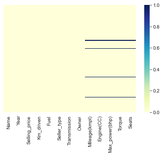

```python
sns.heatmap(car_ds.isnull(),yticklabels=False,cbar=True, cmap="YlGnBu")
```

**Percentage of null values and non-null values in each attribute of the dataset before handling the missing values**

```python
p_missing=car_ds.isnull().sum()*100/len(car_ds)
non_null=car_ds.notnull().sum()*100/len(car_ds)
df_p_missing=pd.DataFrame({'Attribute':car_ds.columns,'Percentage of null values':p_missing, 'Percentage of non-null values':non_null})
df_p_missing
```

|  | Attribute | Percentage of null values | Percentage of non-null values |
| --- | --- | --- | --- |
| Name | Name | 0.000000 | 100.000000 |
| Year | Year | 0.000000 | 100.000000 |
| Selling_price | Selling_price | 0.000000 | 100.000000 |
| Km_driven | Km_driven | 0.000000 | 100.000000 |
| Fuel | Fuel | 0.000000 | 100.000000 |
| Seller_type | Seller_type | 0.000000 | 100.000000 |
| Transmission | Transmission | 0.000000 | 100.000000 |
| Owner | Owner | 0.000000 | 100.000000 |
| Mileage(kmpl) | Mileage(kmpl) | 3.003176 | 96.996824 |
| Engine(CC) | Engine(CC) | 3.003176 | 96.996824 |
| Max_power(bhp) | Max_power(bhp) | 2.974300 | 97.025700 |
| Torque | Torque | 3.017615 | 96.982385 |
| Seats | Seats | 3.003176 | 96.996824 |

**Imputing missing values in Milegae(kmpl) column with mean of mileage**

```python
mileage_mean=car_ds['Mileage(kmpl)'].mean()
mileage_mean
```

```
19.465309615957125
```

```python
car_ds['Mileage(kmpl)'].fillna(mileage_mean,inplace=True)
```

**Imputing missing values in Engine(CC) column with its mean**

```python
engine_mean=car_ds['Engine(CC)'].mean()
engine_mean
```

```
1430.8913367073533
```

```python
car_ds['Engine(CC)'].fillna(engine_mean,inplace=True)
```

**Imputing missing values in Max_power(bhp) column with its mean**

```python
Maxpower_mean=car_ds['Max_power(bhp)'].mean()
Maxpower_mean
```

```
87.72691889880849
```

```python
car_ds['Max_power(bhp)'].fillna(Maxpower_mean,inplace=True)
```

**Removing the attribute Torque from the dataset as it has inconsistent instances**

```python
car_ds.drop('Torque',axis=1,inplace=True)
```

**Imputing missing values in Seats column with mode**

```python
seat_mode=car_ds['Seats'].mode()[0]
seat_mode
```

```
'five'
```

```python
car_ds['Seats'].fillna(seat_mode,inplace=True)
```

```python
car_ds.isnull().sum()
```

```
Name              0
Year              0
Selling_price     0
Km_driven         0
Fuel              0
Seller_type       0
Transmission      0
Owner             0
Mileage(kmpl)     0
Engine(CC)        0
Max_power(bhp)    0
Seats             0
dtype: int64
```

**Percentage of null values and non-null values in each attribute of the dataset after handling the missing values**

```python
p_missing=car_ds.isnull().sum()*100/len(car_ds)
non_null=car_ds.notnull().sum()*100/len(car_ds)
df_p_missing=pd.DataFrame({'Attribute':car_ds.columns,'Percentage of null values':p_missing, 'Percentage of non-null values':non_null})
df_p_missing
```

|  | Attribute | Percentage of null values | Percentage of non-null values |
| --- | --- | --- | --- |
| Name | Name | 0.0 | 100.0 |
| Year | Year | 0.0 | 100.0 |
| Selling_price | Selling_price | 0.0 | 100.0 |
| Km_driven | Km_driven | 0.0 | 100.0 |
| Fuel | Fuel | 0.0 | 100.0 |
| Seller_type | Seller_type | 0.0 | 100.0 |
| Transmission | Transmission | 0.0 | 100.0 |
| Owner | Owner | 0.0 | 100.0 |
| Mileage(kmpl) | Mileage(kmpl) | 0.0 | 100.0 |
| Engine(CC) | Engine(CC) | 0.0 | 100.0 |
| Max_power(bhp) | Max_power(bhp) | 0.0 | 100.0 |
| Seats | Seats | 0.0 | 100.0 |

# OUTLIER DETECTION

**Detecting outliers in each attribute by visualising with boxplot and using IQR**

```python
def outlier_detection(attribute):
    for i in car_ds.columns:
        if(car_ds[i].dtypes=='float64' or car_ds[i].dtypes=='int64'):
            print("Attribute: ",i)
            print(" ")
            print("Description of the attribute: ",i)
            print(" ")
            print(car_ds[i].describe())
            print(" ")

            Q_1=car_ds[i].quantile(0.25)
            Q_3=car_ds[i].quantile(0.75)
            IQR=Q_3 - Q_1
            print("The Inter Quantile Range is: ",IQR)
            print(" ")
            lower_boundary = Q_1 - 1.5 * IQR
            upper_boundary = Q_3 + 1.5 * IQR
            print("The lower boundary is: ",lower_boundary)
            print(" ")
            print("The upper boundary is: ",upper_boundary)
            print(" ")

            l=[]
            for j in car_ds[i]:
                if (j > upper_boundary or j < lower_boundary):
                    l.append(j)
            print("The outliers in the attribute ",i + " is " + str(l))
            print(" ")

            fig=plt.figure(figsize=(8,5))
            sns.boxplot(x=car_ds[i])
            print("Boxplot to detect the outliers: ")
            plt.show()
            print(" ")

            print("If the instances lie between " + str(lower_boundary) + " and " + str(upper_boundary) + " then they are not outliers")
            print(" ")
            print("If the instances lie below " + str(lower_boundary) + " or lie beyond " + str(upper_boundary) + " then they are outliers")
            print(" ")
```

```
Attribute:  Selling_price

Description of the attribute:  Selling_price

count    6.926000e+03
mean     5.172707e+05
std      5.197670e+05
min      2.999900e+04
25%      2.500000e+05
50%      4.000000e+05
75%      6.335000e+05
max      1.000000e+07
Name: Selling_price, dtype: float64

The Inter Quantile Range is:  383500.0

The lower boundary is:  -325250.0

The upper boundary is:  1208750.0

The outliers in the attribute  Selling_price is [2100000, 1500000, 1450000, 1650000, 1750000, 1590000, 1689999, 1425000, 1700000, 2500000, 1700000, 3975000, 5150000, 3200000, 4100000, 4500000, 6000000, 3790000, 2150000, 5800000, 1864999, 2700000, 1750000, 3400000, 2650000, 5850000, 2625000, 2550000,…

Boxplot to detect the outliers:
```

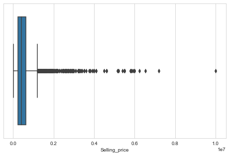

```
If the instances lie between -325250.0 and 1208750.0 then they are not outliers

If the instances lie below -325250.0 or lie beyond 1208750.0 then they are outliers

Attribute:  Km_driven

Description of the attribute:  Km_driven

count    6.926000e+03
mean     7.399568e+04
std      5.835810e+04
min      1.000000e+00
25%      4.000000e+04
50%      7.000000e+04
75%      1.000000e+05
max      2.360457e+06
Name: Km_driven, dtype: float64

The Inter Quantile Range is:  60000.0

The lower boundary is:  -50000.0

The upper boundary is:  190000.0

The outliers in the attribute  Km_driven is [193000, 207890, 240000, 214000, 214000, 265000, 250000, 201850, 221889, 300000, 200000, 193623, 219000, 195000, 360003, 206000, 300000, 200000, 210000, 216000, 210000, 200000, 227000, 334000, 200000, 217000, 1500000, 202000, 205000, 225000, 300000, 375000…

Boxplot to detect the outliers:
```

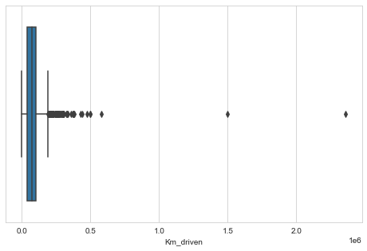

```
If the instances lie between -50000.0 and 190000.0 then they are not outliers

If the instances lie below -50000.0 or lie beyond 190000.0 then they are outliers

Attribute:  Mileage(kmpl)

Description of the attribute:  Mileage(kmpl)

count    6926.000000
mean       19.465310
std         3.987876
min         0.000000
25%        16.950000
50%        19.465310
75%        22.320000
max        42.000000
Name: Mileage(kmpl), dtype: float64

The Inter Quantile Range is:  5.370000000000001

The lower boundary is:  8.894999999999998

The upper boundary is:  30.375

The outliers in the attribute  Mileage(kmpl) is [33.44, 42.0, 0.0, 0.0, 30.46, 0.0, 0.0, 0.0, 32.52, 0.0, 0.0, 33.44, 30.46, 0.0, 32.26, 33.0, 0.0, 0.0, 0.0, 0.0, 0.0, 0.0, 0.0]

Boxplot to detect the outliers:
```

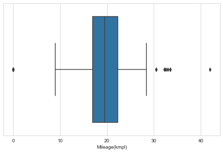

```
If the instances lie between 8.894999999999998 and 30.375 then they are not outliers

If the instances lie below 8.894999999999998 or lie beyond 30.375 then they are outliers

Attribute:  Engine(CC)

Description of the attribute:  Engine(CC)

count    6926.000000
mean     1430.891337
std       486.025467
min       624.000000
25%      1197.000000
50%      1248.000000
75%      1498.000000
max      3604.000000
Name: Engine(CC), dtype: float64

The Inter Quantile Range is:  301.0

The lower boundary is:  745.5

The upper boundary is:  1949.5

The outliers in the attribute  Engine(CC) is [2179.0, 2982.0, 2494.0, 2143.0, 2477.0, 2755.0, 2494.0, 1968.0, 1968.0, 2143.0, 2982.0, 2494.0, 1998.0, 2179.0, 2179.0, 1968.0, 2487.0, 1999.0, 3604.0, 1999.0, 2987.0, 1995.0, 1995.0, 2143.0, 1969.0, 2967.0, 2987.0, 2497.0, 1999.0, 1991.0, 1991.0, 2755.0…

Boxplot to detect the outliers:
```

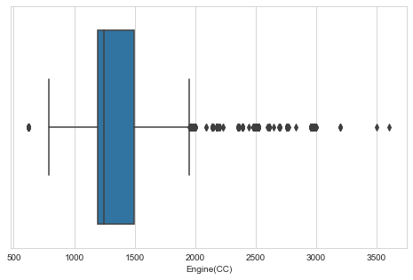

```
If the instances lie between 745.5 and 1949.5 then they are not outliers

If the instances lie below 745.5 or lie beyond 1949.5 then they are outliers

Attribute:  Max_power(bhp)

Description of the attribute:  Max_power(bhp)

count    6926.000000
mean       87.726919
std        31.295492
min         0.000000
25%        68.000000
50%        81.860000
75%        99.000000
max       400.000000
Name: Max_power(bhp), dtype: float64

The Inter Quantile Range is:  31.0

The lower boundary is:  21.5

The upper boundary is:  145.5

The outliers in the attribute  Max_power(bhp) is [160.77, 168.5, 175.56, 171.5, 174.33, 187.74, 170.0, 168.5, 189.0, 160.0, 155.0, 188.0, 214.56, 177.0, 280.0, 148.31, 254.79, 187.74, 190.0, 177.46, 204.0, 190.0, 241.4, 282.0, 150.0, 147.5, 177.0, 147.5, 183.0, 181.04, 171.5, 190.0, 157.7, 190.0, 16…

Boxplot to detect the outliers:
```

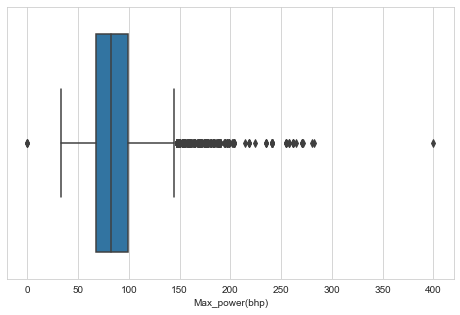

```
If the instances lie between 21.5 and 145.5 then they are not outliers

If the instances lie below 21.5 or lie beyond 145.5 then they are outliers
```

```python
outlier_detection(car_ds)
```

**Outliers in each attribute is treated using 10th and 90th percentile**

```python
def outlier_treatment(attribute):
    for i in car_ds.columns:
        if(car_ds[i].dtypes=='float64' or car_ds[i].dtypes=='int64'):
            tenth_percentile=car_ds[i].quantile(0.10)
            ninetieth_percentile=car_ds[i].quantile(0.90)
            print("Tenth_percentile is :",tenth_percentile)
            print("Ninetieth_percentile is :",ninetieth_percentile)
            print(" ")

            car_ds[i].where(car_ds[i]>tenth_percentile, tenth_percentile, inplace=True)
            car_ds[i].where(car_ds[i]<ninetieth_percentile, ninetieth_percentile, inplace=True)
```

```python
outlier_treatment(car_ds)
```

```
Tenth_percentile is : 145000.0
Ninetieth_percentile is : 900000.0

Tenth_percentile is : 20000.0
Ninetieth_percentile is : 120000.0

Tenth_percentile is : 14.0
Ninetieth_percentile is : 24.7

Tenth_percentile is : 993.0
Ninetieth_percentile is : 2179.0

Tenth_percentile is : 57.6
Ninetieth_percentile is : 126.3
```

**Description and Visualization of the attributes after outlier treatment**

```python
def after_treatment(attribute):
    for i in car_ds.columns:
        if(car_ds[i].dtypes=='float64' or car_ds[i].dtypes=='int64'):
            print("Description of the attribute after outlier treatment: ",i)
            print(" ")
            print(car_ds[i].describe())
            print(" ")

            fig=plt.figure(figsize=(8,5))
            sns.boxplot(x=car_ds[i])
            print("Boxplot after outlier treatment: ")
            plt.show()
            print(" ")
```

```
Description of the attribute after outlier treatment:  Selling_price

count      6926.000000
mean     454552.519636
std      244217.611832
min      145000.000000
25%      250000.000000
50%      400000.000000
75%      633500.000000
max      900000.000000
Name: Selling_price, dtype: float64

Boxplot after outlier treatment:
```

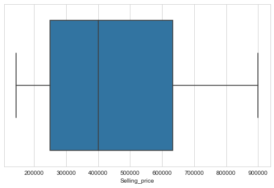

```
Description of the attribute after outlier treatment:  Km_driven

count      6926.000000
mean      69057.258302
std       34532.471719
min       20000.000000
25%       40000.000000
50%       70000.000000
75%      100000.000000
max      120000.000000
Name: Km_driven, dtype: float64

Boxplot after outlier treatment:
```

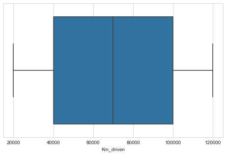

```
Description of the attribute after outlier treatment:  Mileage(kmpl)

count    6926.000000
mean       19.463883
std         3.371956
min        14.000000
25%        16.950000
50%        19.465310
75%        22.320000
max        24.700000
Name: Mileage(kmpl), dtype: float64

Boxplot after outlier treatment:
```

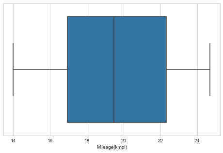

```
Description of the attribute after outlier treatment:  Engine(CC)

count    6926.000000
mean     1413.250563
std       379.069375
min       993.000000
25%      1197.000000
50%      1248.000000
75%      1498.000000
max      2179.000000
Name: Engine(CC), dtype: float64

Boxplot after outlier treatment:
```

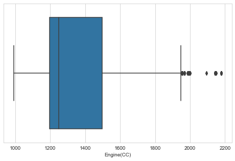

```
Description of the attribute after outlier treatment:  Max_power(bhp)

count    6926.000000
mean       85.631686
std        21.381658
min        57.600000
25%        68.000000
50%        81.860000
75%        99.000000
max       126.300000
Name: Max_power(bhp), dtype: float64

Boxplot after outlier treatment:
```

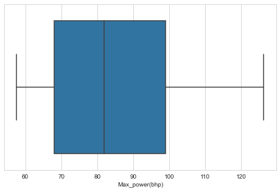

```python
after_treatment(car_ds)
```

# NORMALIZING NUMERICAL ATTRIBUTES USING NORMALIZATION/MIN MAX SCALING

```python
car_norm=car_ds.copy()
car_norm.head()
```

|  | Name | Year | Selling_price | Km_driven | Fuel | Seller_type | Transmission | Owner | Mileage(kmpl) | Engine(CC) | Max_power(bhp) | Seats |
| --- | --- | --- | --- | --- | --- | --- | --- | --- | --- | --- | --- | --- |
| 0 | Maruti Swift Dzire VDI | 2014 | 450000 | 120000 | Diesel | Individual | Manual | First Owner | 23.40 | 1248.0 | 74.00 | five |
| 1 | Skoda Rapid 1.5 TDI Ambition | 2014 | 370000 | 120000 | Diesel | Individual | Manual | Second Owner | 21.14 | 1498.0 | 103.52 | five |
| 2 | Honda City 2017-2020 EXi | 2006 | 158000 | 120000 | Petrol | Individual | Manual | Third Owner | 17.70 | 1497.0 | 78.00 | five |
| 3 | Hyundai i20 Sportz Diesel | 2010 | 225000 | 120000 | Diesel | Individual | Manual | First Owner | 23.00 | 1396.0 | 90.00 | five |
| 4 | Maruti Swift VXI BSIII | 2007 | 145000 | 120000 | Petrol | Individual | Manual | First Owner | 16.10 | 1298.0 | 88.20 | five |

```python
def minmax_scale(attribute):

    x_min = min(attribute,key=lambda x:float(x))
    x_max = max(attribute,key=lambda x:float(x))

    norm=[]
    for i in attribute:
        x_dash=(i-x_min)/(x_max-x_min)
        norm.append(x_dash)
        attribute.replace(i,x_dash,inplace=True)

    print("Some normalized values: ",norm[:10])
    print(" ")

    print("Scatterplot of normalized values:")

    fig=plt.figure(figsize=(10,10))
    sns.scatterplot(x=norm,y=car_ds.index,color='m',marker='*')
```

# NORMALIZATION OF SELLING_PRICE

```
Some normalized values:  [0.40397350993377484, 0.2980132450331126, 0.017218543046357615, 0.10596026490066225, 0.0, 0.39072847682119205, 0.0, 0.0, 0.271523178807947, 0.0728476821192053]

Scatterplot of normalized values:
```

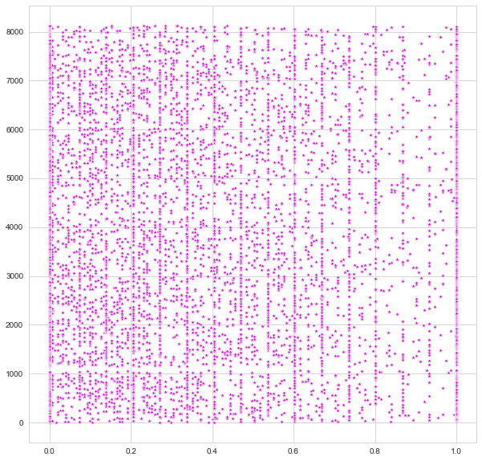

```python
minmax_scale(car_norm['Selling_price'])
```

# NORMALIZATION OF KM_DRIVEN

```
Some normalized values:  [1.0, -0.19999, -0.19999, -0.19999, -0.19999, 0.25, -0.19999, 0.0, 0.7, -0.19999]

Scatterplot of normalized values:
```

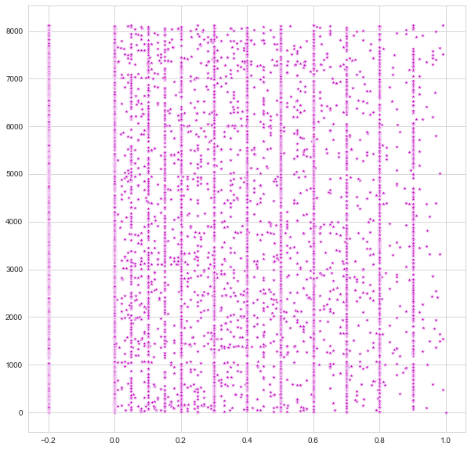

```python
minmax_scale(car_norm['Km_driven'])
```

# NORMALIZATION OF MILEAGE(KMPL)

```
Some normalized values:  [0.8785046728971961, 0.6672897196261683, 0.34579439252336447, 0.8411214953271029, 0.1962616822429908, 0.5738317757009347, 0.3084112149532711, -1.2900690016595338, 0.8962616822429907, 0.5607476635514019]

Scatterplot of normalized values:
```

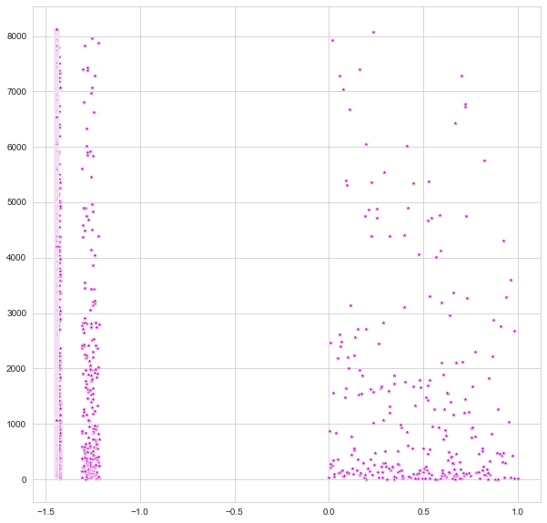

```python
minmax_scale(car_norm['Mileage(kmpl)'])
```

# NORMALIZATION OF ENGINE(CC)

```
Some normalized values:  [0.21500843170320405, 0.4258010118043845, 0.42495784148397975, 0.33979763912310285, 0.2571669477234401, 0.17200674536256325, 0.05733558178752108, 0.0, 0.3128161888701518, 0.342327150084317]

Scatterplot of normalized values:
```

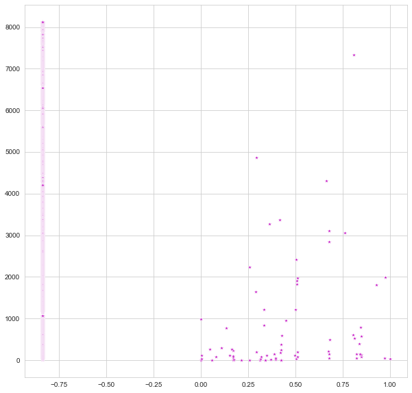

```python
minmax_scale(car_norm['Engine(CC)'])
```

# NORMALIZATION OF MAX_POWER(BHP)

```
Some normalized values:  [0.23871906841339158, 0.6684133915574964, 0.29694323144104806, 0.4716157205240175, 0.44541484716157215, 0.35312954876273656, 0.0, -0.8384279475982535, 0.13828238719068406, 0.15283842794759817]

Scatterplot of normalized values:
```

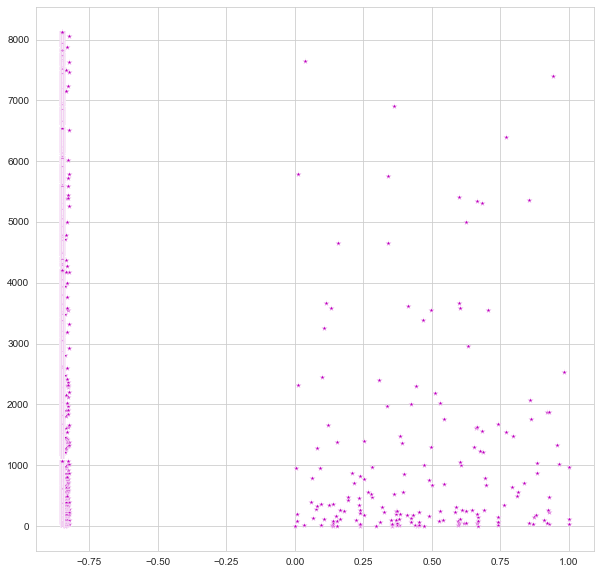

```python
minmax_scale(car_norm['Max_power(bhp)'])
```

# ENCODING CATEGORICAL VARIABLES USING ONE HOT ENCODING

```python
car_encoder=ce.OneHotEncoder(cols=['Name','Year','Fuel','Seller_type','Transmission','Owner','Seats'],handle_unknown='return_nan',return_df=True,use_cat_names=True)
car_val=car_encoder.fit_transform(car_ds)
car_val
```

|  | Name_Maruti Swift Dzire VDI | Name_Skoda Rapid 1.5 TDI Ambition | Name_Honda City 2017-2020 EXi | Name_Hyundai i20 Sportz Diesel | Name_Maruti Swift VXI BSIII | Name_Hyundai Xcent 1.2 VTVT E Plus | Name_Maruti Wagon R LXI DUO BSIII | Name_Maruti 800 DX BSII | Name_Toyota Etios VXD | Name_Ford Figo Diesel Celebration Edition | ... | Max_power(bhp) | Seats_five | Seats_four | Seats_seven | Seats_eight | Seats_six | Seats_nine | Seats_ten | Seats_fourteen | Seats_two |
| --- | --- | --- | --- | --- | --- | --- | --- | --- | --- | --- | --- | --- | --- | --- | --- | --- | --- | --- | --- | --- | --- |
| 0 | 1.0 | 0.0 | 0.0 | 0.0 | 0.0 | 0.0 | 0.0 | 0.0 | 0.0 | 0.0 | ... | 74.00 | 1.0 | 0.0 | 0.0 | 0.0 | 0.0 | 0.0 | 0.0 | 0.0 | 0.0 |
| 1 | 0.0 | 1.0 | 0.0 | 0.0 | 0.0 | 0.0 | 0.0 | 0.0 | 0.0 | 0.0 | ... | 103.52 | 1.0 | 0.0 | 0.0 | 0.0 | 0.0 | 0.0 | 0.0 | 0.0 | 0.0 |
| 2 | 0.0 | 0.0 | 1.0 | 0.0 | 0.0 | 0.0 | 0.0 | 0.0 | 0.0 | 0.0 | ... | 78.00 | 1.0 | 0.0 | 0.0 | 0.0 | 0.0 | 0.0 | 0.0 | 0.0 | 0.0 |
| 3 | 0.0 | 0.0 | 0.0 | 1.0 | 0.0 | 0.0 | 0.0 | 0.0 | 0.0 | 0.0 | ... | 90.00 | 1.0 | 0.0 | 0.0 | 0.0 | 0.0 | 0.0 | 0.0 | 0.0 | 0.0 |
| 4 | 0.0 | 0.0 | 0.0 | 0.0 | 1.0 | 0.0 | 0.0 | 0.0 | 0.0 | 0.0 | ... | 88.20 | 1.0 | 0.0 | 0.0 | 0.0 | 0.0 | 0.0 | 0.0 | 0.0 | 0.0 |
| ... | ... | ... | ... | ... | ... | ... | ... | ... | ... | ... | ... | ... | ... | ... | ... | ... | ... | ... | ... | ... | ... |
| 8121 | 0.0 | 0.0 | 0.0 | 0.0 | 0.0 | 0.0 | 0.0 | 0.0 | 0.0 | 0.0 | ... | 67.10 | 1.0 | 0.0 | 0.0 | 0.0 | 0.0 | 0.0 | 0.0 | 0.0 | 0.0 |
| 8122 | 0.0 | 0.0 | 0.0 | 0.0 | 0.0 | 0.0 | 0.0 | 0.0 | 0.0 | 0.0 | ... | 88.73 | 1.0 | 0.0 | 0.0 | 0.0 | 0.0 | 0.0 | 0.0 | 0.0 | 0.0 |
| 8123 | 0.0 | 0.0 | 0.0 | 0.0 | 0.0 | 0.0 | 0.0 | 0.0 | 0.0 | 0.0 | ... | 82.85 | 1.0 | 0.0 | 0.0 | 0.0 | 0.0 | 0.0 | 0.0 | 0.0 | 0.0 |
| 8124 | 0.0 | 0.0 | 0.0 | 0.0 | 0.0 | 0.0 | 0.0 | 0.0 | 0.0 | 0.0 | ... | 110.00 | 1.0 | 0.0 | 0.0 | 0.0 | 0.0 | 0.0 | 0.0 | 0.0 | 0.0 |
| 8125 | 0.0 | 0.0 | 0.0 | 0.0 | 0.0 | 0.0 | 0.0 | 0.0 | 0.0 | 0.0 | ... | 73.90 | 1.0 | 0.0 | 0.0 | 0.0 | 0.0 | 0.0 | 0.0 | 0.0 | 0.0 |

6926 rows × 2115 columns

# VARIATE ANALYSIS

# UNIVARIATE ANALYSIS

# UNIVARIATE KDE PLOT

**To analyse the probability density of the vehicle's mileage in kmpl**

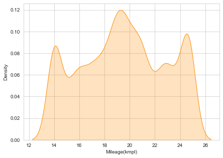

```python
fig=plt.figure(figsize=(7,5))
sns.kdeplot(car_ds['Mileage(kmpl)'],shade=True,color='darkorange')
```

# INFERENCE:

**The above Kdeplot shows that the probability distribution is higher in the range of 18kmpl to 20 kmpl mileage. So many used vehicles have the mileage in this range.**

# UNIVARIATE HISTPLOT

**To analyse the vehicle's engine capacity**

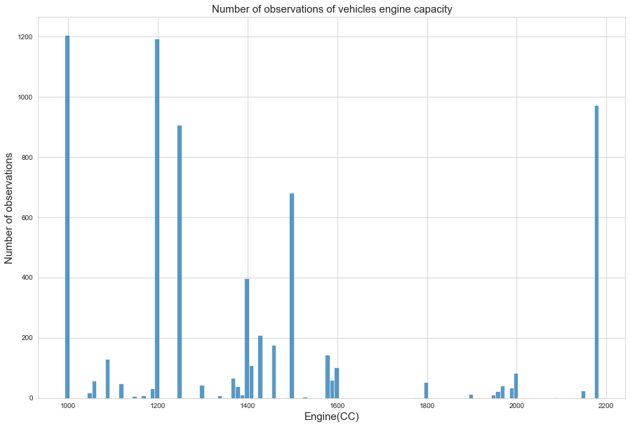

```python
fig=plt.figure(figsize=(15,10))
plot=sns.histplot(car_ds['Engine(CC)'],binwidth=10)
plot.set_xlabel('Engine(CC)',fontsize=15)
plot.set_ylabel('Number of observations',fontsize=15)
plot.set_title('Number of observations of vehicles engine capacity',fontsize=15)
```

# INFERENCE:

# UNIVARIATE PIECHART

**To analyse the percentage of different kinds of owners**

```python
owner=car_ds['Owner'].value_counts()
owner
```

```
First Owner             4242
Second Owner            1974
Third Owner              536
Fourth & Above Owner     169
Test Drive Car             5
Name: Owner, dtype: int64
```

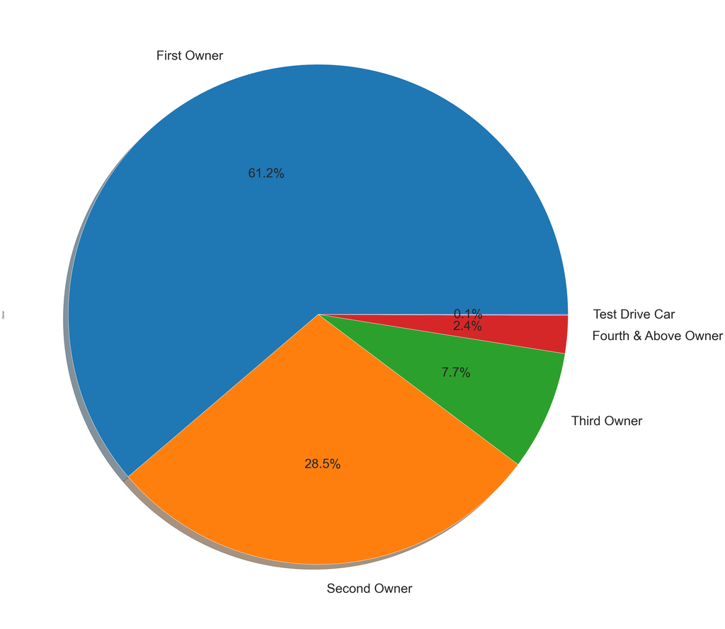

```python
plt.piecolor=sns.color_palette('pastel')[0:5]
label=list(owner.index)
owner.plot.pie(autopct='%1.1f%%',labels=label,figsize=(50,40),fontsize=45,shadow=True)
```

# INFERENCE:

**Most of the used vehicles belong to their first owner and least number of vehicles are used as test drive car**

# UNIVARIATE BAR PLOT

**To analyse the number of vehicles that have four seats**

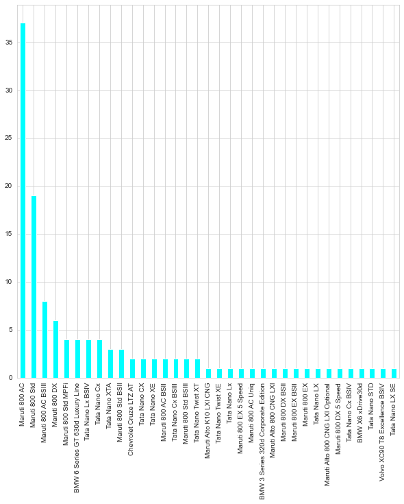

```python
val=car_ds.loc[car_ds['Seats']=='four']
val_cat=val['Name'].value_counts()
fig=plt.figure(figsize=(10,10))
val_cat.plot.bar(color='cyan')
```

# INFERENCE:

**The above barplot shows that most number of Maruti 800 AC vehicles have 4 seats**

# UNIVARIATE COUNTPLOT

**To analyse the number of vehicles that were bought in each year**

```python
car_ds['Year'].value_counts()
```

```
2017    808
2016    693
2015    681
2018    608
2012    604
2014    581
2013    562
2011    554
2010    380
2019    347
2009    240
2008    205
2007    176
2006    123
2005     91
2020     63
2004     60
2003     47
2002     26
2000     20
1999     17
1997     11
1998     10
2001      9
1996      3
1994      3
1995      2
1983      1
1991      1
Name: Year, dtype: int64
```

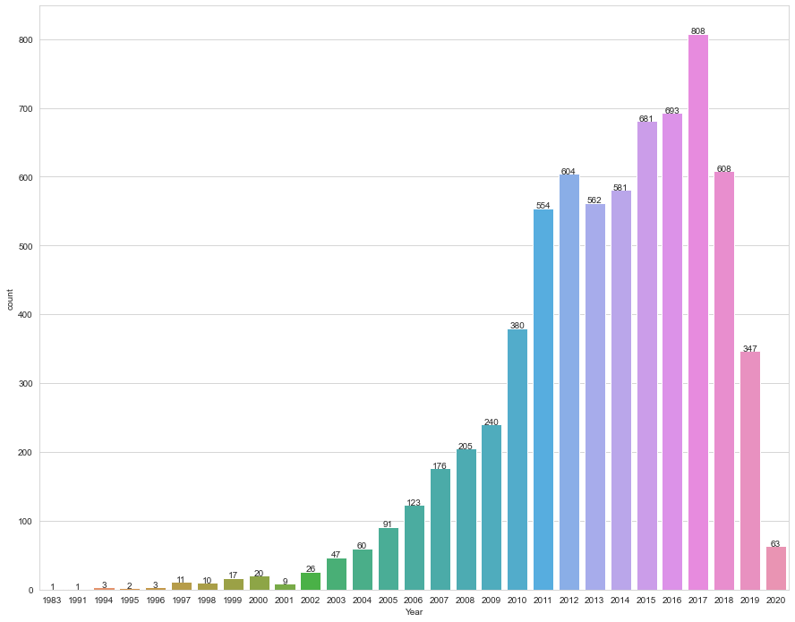

```python
fig, ax=plt.subplots(figsize=(15,12))
cplot=sns.countplot(ax=ax,x=car_ds['Year'])
for i in cplot.patches:
    h=i.get_height()
    cplot.text(i.get_x()+i.get_width()/2.,h+0.1,h,ha="center")
```

# INFERENCE:

**The above counplot shows that most vehicles were bought in the year 2017 and least number of vehicles were bought during 1983 and 1991**

# UNIVARIATE BOXPLOT

```python
car_ds['Max_power(bhp)'].describe()
```

```
count    6926.000000
mean       85.631686
std        21.381658
min        57.600000
25%        68.000000
50%        81.860000
75%        99.000000
max       126.300000
Name: Max_power(bhp), dtype: float64
```

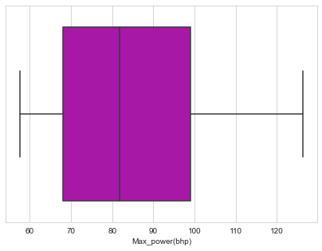

```python
fig=plt.figure(figsize=(7,5))
sns.boxplot(car_ds['Max_power(bhp)'],color='m')
```

**The above boxplot shows that the minimum max power lies below 60bhp and maximum max power lies above 120bhp**

# UNIVARIATE ANALYSIS OF NUMERICAL AND CATEGORICAL VARIABLES

**To analyze the number of vehicles that belong to each category in the categorical attributes and to analyze the distribution of each value in the numerical attributes**

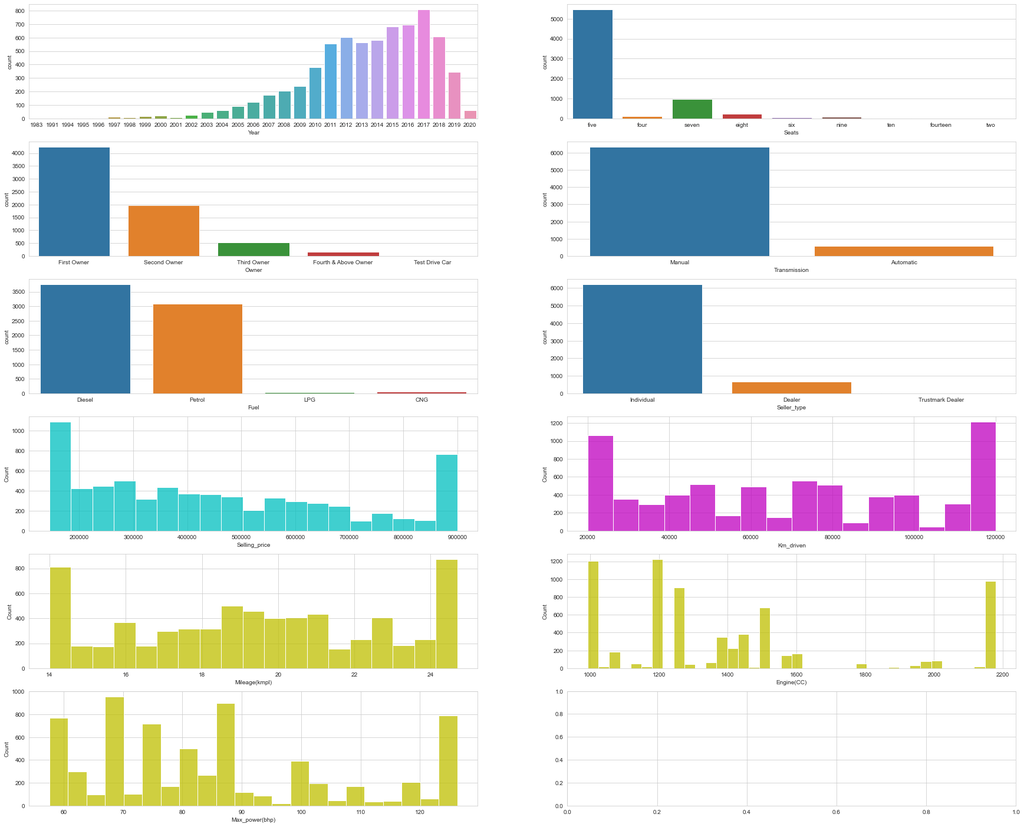

```python
fig,ax = plt.subplots(6,2,figsize=(30,25))
sns.countplot(car_ds['Year'],ax=ax[0,0])
sns.countplot(car_ds['Seats'],ax=ax[0,1])
sns.countplot(car_ds['Owner'],ax=ax[1,0])
sns.countplot(car_ds['Transmission'],ax=ax[1,1])
sns.countplot(car_ds['Fuel'],ax=ax[2,0])
sns.countplot(car_ds['Seller_type'],ax=ax[2,1])
sns.histplot(car_ds['Selling_price'],ax=ax[3,0],color='c')
sns.histplot(car_ds['Km_driven'],ax=ax[3,1],color='m')
sns.histplot(car_ds['Mileage(kmpl)'],ax=ax[4,0],color='y')
sns.histplot(car_ds['Engine(CC)'],ax=ax[4,1],color='y')
sns.histplot(car_ds['Max_power(bhp)'],ax=ax[5,0],color='y')
```

# INFERENCE:

# BIVARIATE ANALYSIS

# LINE PLOT USING REGPLOT

**To analyse the relationship between fuel and engine capacity**

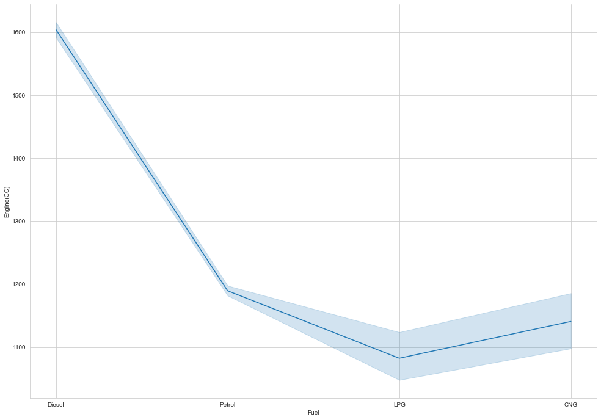

```python
sns.relplot(car_ds['Fuel'],car_ds['Engine(CC)'],kind='line',markers=True)
plt.gcf().set_size_inches(15,10)
```

# INFERENCE:

**The above line plot shows that vehicles that use diesel have more engine capacity and LPG vehicles have least engine capacity**

# DISPLOT

**Displot plots histogram by default. It also has other kinds like kdeplot, rugplot, jointplot.**

# HISTOGRAM USING DISPLOT

**To analyse how many vehciles were bought during each year with respect to their owner type**

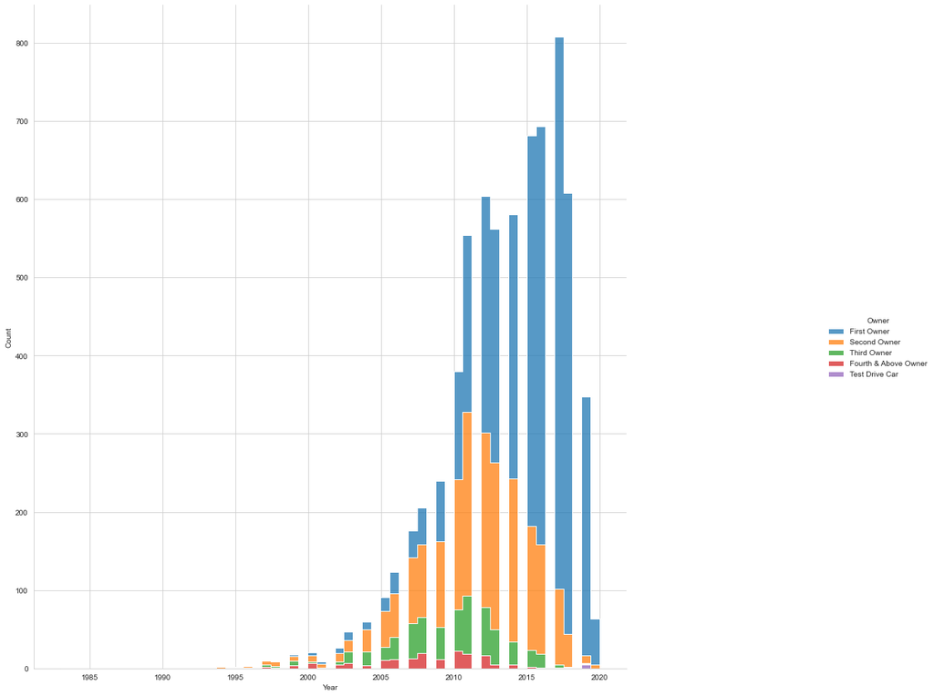

```python
sns.displot(car_ds,x='Year',hue='Owner',element='step',multiple='stack')
plt.gcf().set_size_inches(18,14)
```

# INFERENCE:

**The above histogram shows that in the year 2017 more vehicles were bought and these vehicles belong to first owner.**

# KDEPLOT USING DISPLOT

**To analyse the relationship of km driven with respect to the type of fuel they use**

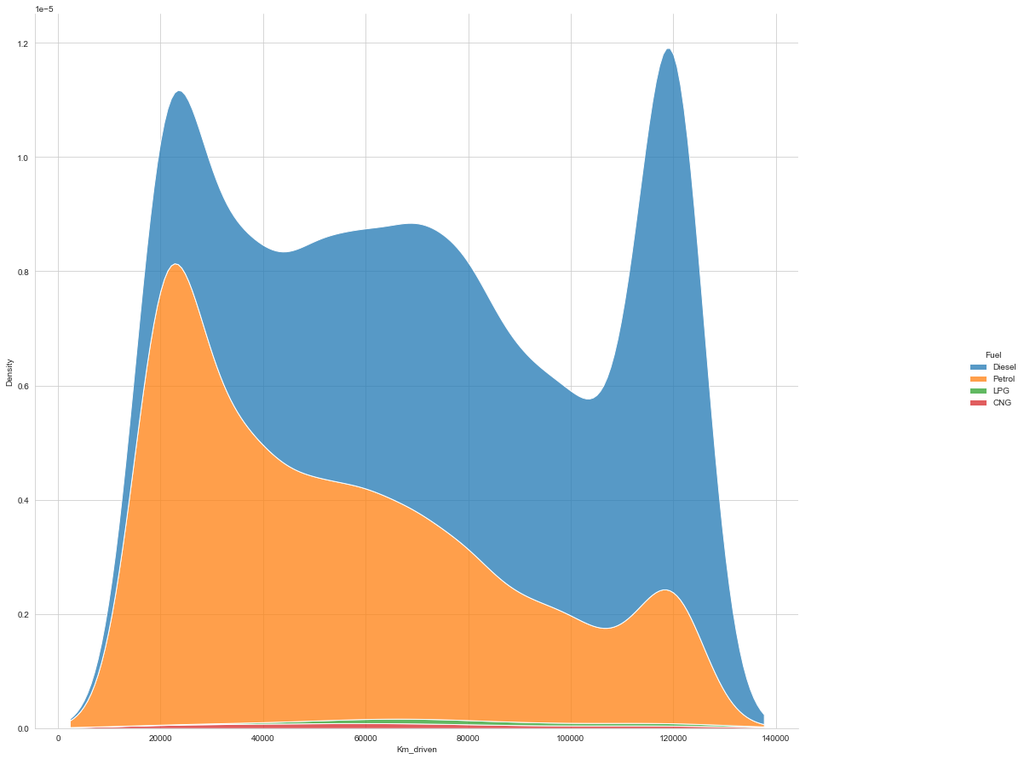

```python
sns.displot(car_ds,x='Km_driven',hue='Fuel',kind='kde',multiple='stack')
plt.gcf().set_size_inches(18,14)
```

# INFERENCE:

# JOINTPLOT

**To analyse the relationship between mileage and engine capacity of used vehicle**

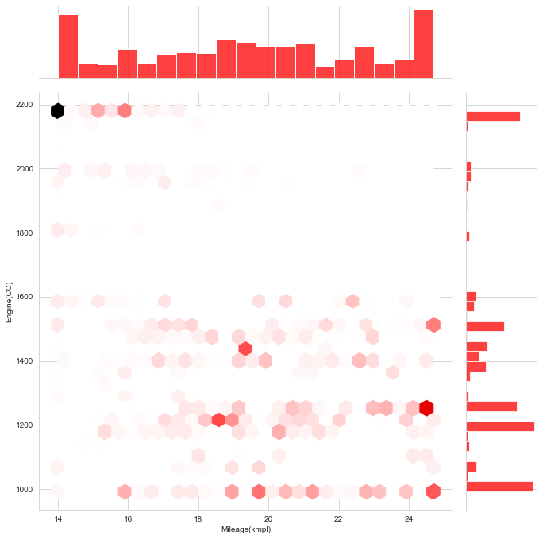

```python
sns.jointplot(car_ds['Mileage(kmpl)'],car_ds['Engine(CC)'],color='r',kind='hex')
plt.gcf().set_size_inches(10,10)
```

# INFERENCE:

**The above jointplot shows that many vehicles with a mileage of 14kmpl has an engine capacity of around 2200CC.**

# COUNTPLOT

**To analyse the number of vehicles that have different transmission and fuel type with their mileage being less than 14.5kmpl**

```python
mile=car_ds.loc[car_ds['Mileage(kmpl)']<14.5]
```

```
posx and posy should be finite values
posx and posy should be finite values
posx and posy should be finite values
posx and posy should be finite values
```

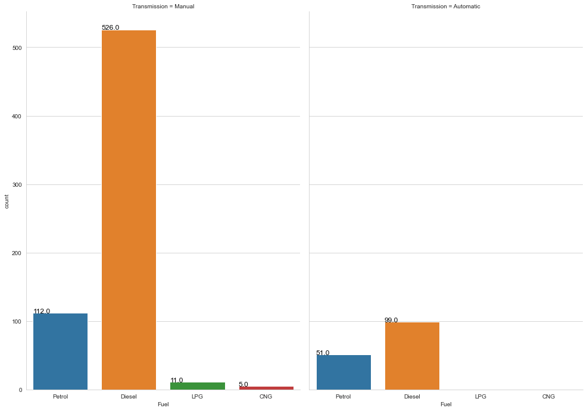

```python
x=sns.catplot(x='Fuel',col='Transmission',kind='count',data=mile)
x.fig.set_size_inches(16,12)
x.fig.subplots_adjust(top=0.81,right=0.86)

ax=x.facet_axis(0,0)
for i in ax.patches:
    ax.text(i.get_x(),i.get_height()*1.0,'{0:.1f}'.format(i.get_height()),color='k',size='large')

ax=x.facet_axis(0,1)
for i in ax.patches:
    ax.text(i.get_x(),i.get_height()*1.0,'{0:.1f}'.format(i.get_height()),color='k',size='large')
```

# INFERENCE:

**The above countplot shows that most vehicles that use diesel and are manual have mileage less than 14.5kmpl while least vehicles that use CNG and are manual have mileage less than 14.5kmpl**

# BIVARIATE BARPLOT

**To analyse the relationship between fuel type and number of kilometers driven**

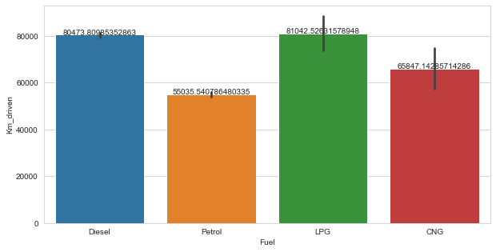

```python
fig,ax = plt.subplots(1,1, figsize=(10,5))
x=sns.barplot(car_ds['Fuel'],car_ds['Km_driven'])
for i in x.patches:
    height = i.get_height()
    x.text(i.get_x()+i.get_width()/2., height + 1,height ,ha="center")
```

# INFERENCE:

**The above barplot shows that vehicles that use LPG have driven more kilometers when compared to vehicles that use petrol, diesel and CNG**

# BIVARIATE KDE PLOT

**To analyse the relationship between selling price and seats in the vehicle**

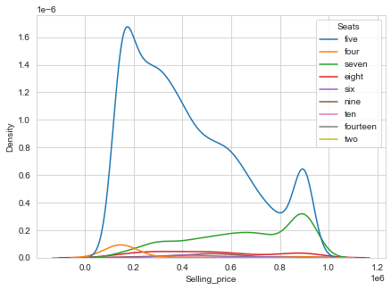

```python
sns.kdeplot(data=car_ds,x='Selling_price',hue='Seats')
plt.gcf().set_size_inches(7,5)
```

# INFERENCE:

# MUTLIVARIATE ANALYSIS

# MULTIVARIATE BARPLOT

**To analyse the number of vehicles that belong to a particular seller type and engine capacity with respect to the fuel type**

```
posx and posy should be finite values
posx and posy should be finite values
posx and posy should be finite values
posx and posy should be finite values
posx and posy should be finite values
posx and posy should be finite values
```

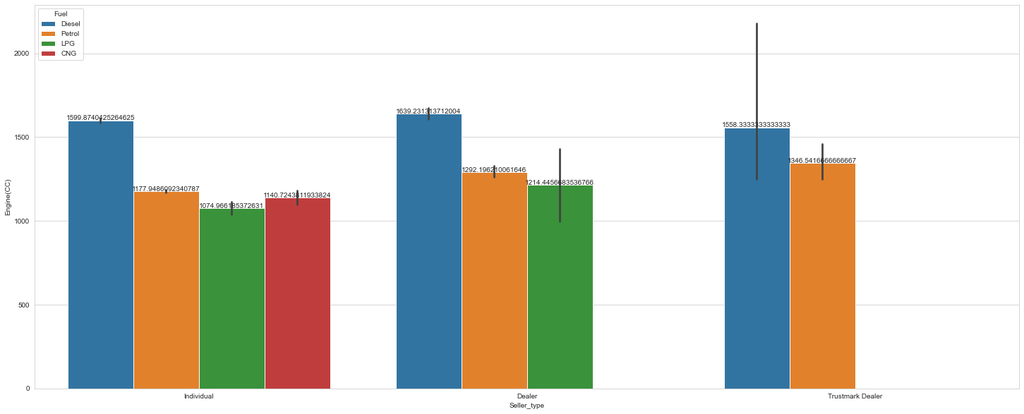

```python
fig,ax = plt.subplots(1,1, figsize=(25,10))
x=sns.barplot(car_ds['Seller_type'],car_ds['Engine(CC)'],hue=car_ds['Fuel'])
for i in x.patches:
    height = i.get_height()
    x.text(i.get_x()+i.get_width()/2., height + 1,height ,ha="center")
```

# INFERENCE:

# MULTIVARIATE BOXPLOT

**To analyse the relationship between owner and the number of kilometers driven by them with respect to their seller type**

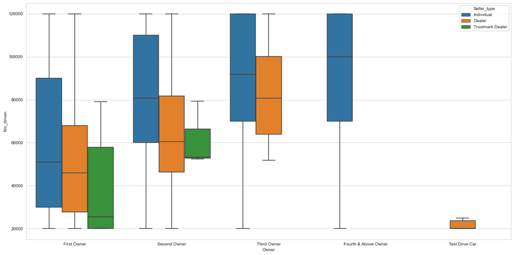

```python
fig=plt.figure(figsize=(20,10))
sns.boxplot(x='Owner',y='Km_driven',hue='Seller_type',data=car_ds)
```

# INFERENCE:

**The above boxplot shows that the vehicle belonging to fourth and above owner has driven more kilometer and it belongs to an individual seller type**